# DADM Stuff: Files and Pins

Author

Robert W. Walker

This page serves principally as a file repository for files I use in Data Analysis, (Modelling), and Decision Making (GSM 5103/GSMPR 622) – DADM.

*NB: It also deploys what I think to be the easiest way to make the various bits of data easily available. Though there is no context at all for this, the first note is how to create a pin for this repository. In this case, it was largely automated by going through and reading the various file types and then writing them out given a collected list.*

```
board <- board_temp(versioned = TRUE)
# pin_write(obj, NameofPin)
board %>% pin_write(MFPerform, "MFPerform")
```

There are a number of files and file types hosted here. All can be accessed via the following table. In a moment, I will take some of the data files and make them particularly easy to access with R’s `pins`. It is worth noting that not everything that is here is a pin, there are a variety of different file types and pins work with `"csv", "json", "rds", "parquet", "arrow", or "qs"`. Only the data.frame type structures are pinned here.

## A List of All Files

```r
library(tidyverse)
Files <- dir()
Files
```

```
  [1] "1109-11PM"
  [2] "3DResult.JPG"
  [3] "AirlineCosts.RData"
  [4] "AlumniGiving.csv"
  [5] "AlumniGiving.RData"
  [6] "AnimalCrossing.xlsx"
  [7] "AnimalCrossingFA21V.xlsx"
  [8] "AoC-1.R"
  [9] "bibliography.bib"
 [10] "Big-Week-6-RSpace.RData"
 [11] "BinomialR.PNG"
 [12] "BondFunds.csv"
 [13] "BondFunds.xlsx"
 [14] "br7983.dta"
 [15] "BrewerSize.gif"
```

[output cut: 104 more lines]

## A Look at the Data

```r
library(DT)
Files.df <- data.frame(Files=Files) %>% mutate(link=paste0(paste0('<a href=',paste0("\"https://github.com/robertwwalker/DADMStuff/raw/master/",Files,"\"", sep=""),' > ', sep=""),Files,'</a>',sep=""))
datatable(Files.df, escape = FALSE)
```

|  | Files | link |
| --- | --- | --- |
| 1 | 1109-11PM | 1109-11PM |
| 2 | 3DResult.JPG | 3DResult.JPG |
| 3 | AirlineCosts.RData | AirlineCosts.RData |
| 4 | AlumniGiving.csv | AlumniGiving.csv |
| 5 | AlumniGiving.RData | AlumniGiving.RData |
| 6 | AnimalCrossing.xlsx | AnimalCrossing.xlsx |
| 7 | AnimalCrossingFA21V.xlsx | AnimalCrossingFA21V.xlsx |
| 8 | AoC-1.R | AoC-1.R |
| 9 | bibliography.bib | bibliography.bib |
| 10 | Big-Week-6-RSpace.RData | Big-Week-6-RSpace.RData |

[output cut: 109 more lines]

I want to make these files accessible. Apparently, the way to do this is `pins`.

I am going to put the pins on github. The repository will be: `https://raw.githubcontent.com/robertwwalker/DADMStuff/pins/`. Here is a list of the pins.

```r
dir("pins/")
```

```
 [1] "_pins.yaml"      "AirlineCosts"    "BondFunds"       "brexit"
 [5] "CEOComp"         "Churn"           "Concrete"        "corbyn"
 [9] "critic"          "datasaurus"      "Defaults"        "Discrimination"
[13] "DiscWH"          "dogs"            "EPL"             "EquityChg"
[17] "eu_balance"      "FastFood"        "Fertilizer"      "Financials.Raw"
[21] "Financials.Tidy" "FoodSat"         "GamingDevices"   "GGap"
[25] "Happiness"       "HMB"             "ISQ99_Essex"     "Items"
[29] "MFPerform"       "Mileage"         "Nichelim"        "OregonSalaries"
[33] "pensions"        "PowerPlant"      "Redlining"       "ScarceSteady"
[37] "Semiconductors"  "SSTimes"         "trade"           "UCB.Micro"
[41] "User_reviews"    "Villagers"       "VonBort"         "women_research"
```

## How to use them?

First, we have to call `library(pins)`; I will also require the `tidyverse`.

To set this up on your own, make sure you have the two packages installed.

```
install.packages(c("pins","tidyverse"))
```

Then you will need to define `board` as the collection of pins stored here.

```r
library(pins)
library(tidyverse)
board <- board_url("https://raw.githubusercontent.com/robertwwalker/DADMStuff/master/pins/")
```

Let’s list the pins that are located in `board`

```r
board %>% pin_list()
```

```
 [1] "AirlineCosts"    "BondFunds"       "CEOComp"         "Churn"
 [5] "Concrete"        "Defaults"        "DiscWH"          "Discrimination"
 [9] "EPL"             "EquityChg"       "FastFood"        "Fertilizer"
[13] "Financials.Raw"  "Financials.Tidy" "FoodSat"         "GGap"
[17] "GamingDevices"   "HMB"             "Happiness"       "ISQ99_Essex"
[21] "Items"           "MFPerform"       "Mileage"         "Nichelim"
[25] "OregonSalaries"  "PowerPlant"      "Redlining"       "SSTimes"
[29] "ScarceSteady"    "Semiconductors"  "UCB.Micro"       "User_reviews"
[33] "Villagers"       "VonBort"         "brexit"          "corbyn"
[37] "critic"          "datasaurus"      "dogs"            "eu_balance"
[41] "pensions"        "trade"           "women_research"
```

### An Aside on `pins`

The [`pins`](https://pins.rstudio.com/) package is quite neat. To the extent that there is a limitation, it is the use of flat files. As a result, all of the data contained herein is a single row/column data file of some form or other. If you’d like to learn more about `pins`, the [Getting Started with `pins`](https://pins.rstudio.com/articles/pins.html) on the **RStudio** website is quite useful.

## Acquiring a pin

Acquiring a single dataset is easiest with `pin_read`. In this case, let me create a local object called `EPL` using the “EPL” pinned data.

```r
EPL <- board %>% pin_read("EPL")
```

## There is no difference to working with pins once they are local objects

Having grabbed it, I will plot it (to keep the club names from overlapping, I will deploy `ggrepel` on the labels.)

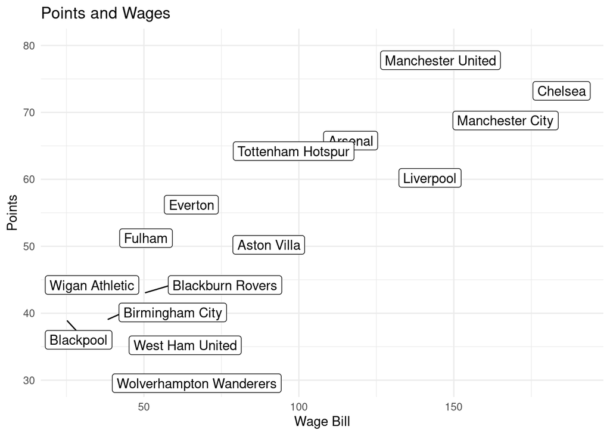

```r
library(ggrepel)
EPL %>%
  ggplot() +
  aes(y=Points, x=Wage.Bill.milGBP, label=Team) +
  geom_label_repel() +
  theme_minimal() +
  labs(x="Wage Bill", y="Points", title="Points and Wages")
```

The process is the same for any of the pins, only renaming the object and pointing to a different “pin”.

```r
knitr::write_bib(names(sessionInfo()$otherPkgs), file="bibliography.bib")
```

## References

Grolemund, Garrett, and Hadley Wickham. 2011. “Dates and Times Made Easy with lubridate.” *Journal of Statistical Software* 40 (3): 1–25. https://www.jstatsoft.org/v40/i03/.

Müller, Kirill, and Hadley Wickham. 2023. *Tibble: Simple Data Frames*. https://tibble.tidyverse.org/.

Silge, Julia, Hadley Wickham, and Javier Luraschi. 2023. *Pins: Pin, Discover and Share Resources*. https://pins.rstudio.com/.

Slowikowski, Kamil. 2023. *Ggrepel: Automatically Position Non-Overlapping Text Labels with Ggplot2*. https://github.com/slowkow/ggrepel.

Spinu, Vitalie, Garrett Grolemund, and Hadley Wickham. 2023. *Lubridate: Make Dealing with Dates a Little Easier*. https://lubridate.tidyverse.org.

Wickham, Hadley. 2016. *Ggplot2: Elegant Graphics for Data Analysis*. Springer-Verlag New York. https://ggplot2.tidyverse.org.

———. 2023a. *Forcats: Tools for Working with Categorical Variables (Factors)*. https://forcats.tidyverse.org/.

———. 2023b. *Stringr: Simple, Consistent Wrappers for Common String Operations*. https://stringr.tidyverse.org.

———. 2023c. *Tidyverse: Easily Install and Load the Tidyverse*. https://tidyverse.tidyverse.org.

Wickham, Hadley, Mara Averick, Jennifer Bryan, Winston Chang, Lucy D’Agostino McGowan, Romain François, Garrett Grolemund, et al. 2019. “Welcome to the tidyverse.” *Journal of Open Source Software* 4 (43): 1686. https://doi.org/10.21105/joss.01686.

Wickham, Hadley, Winston Chang, Lionel Henry, Thomas Lin Pedersen, Kohske Takahashi, Claus Wilke, Kara Woo, Hiroaki Yutani, and Dewey Dunnington. 2023. *Ggplot2: Create Elegant Data Visualisations Using the Grammar of Graphics*. https://ggplot2.tidyverse.org.

Wickham, Hadley, Romain François, Lionel Henry, Kirill Müller, and Davis Vaughan. 2023. *Dplyr: A Grammar of Data Manipulation*. https://dplyr.tidyverse.org.

Wickham, Hadley, and Lionel Henry. 2023. *Purrr: Functional Programming Tools*. https://purrr.tidyverse.org/.

Wickham, Hadley, Jim Hester, and Jennifer Bryan. 2023. *Readr: Read Rectangular Text Data*. https://readr.tidyverse.org.

Wickham, Hadley, Davis Vaughan, and Maximilian Girlich. 2023. *Tidyr: Tidy Messy Data*. https://tidyr.tidyverse.org.

Xie, Yihui, Joe Cheng, and Xianying Tan. 2023. *DT: A Wrapper of the JavaScript Library DataTables*. https://github.com/rstudio/DT.